# Stacking & Meta labeling

- Credit card fraud detection
- Quantitative fundamental trading

先从 Credit card fraud detection 引入 stacking 和 meta labeling 的概念，再嫁接到金融数据上

## 数据分析

```python
'''Main'''
import numpy as np
import pandas as pd
'''Data Viz'''
import matplotlib.pyplot as plt
import seaborn as sns
#plt.style.use('seaborn')
plt.rcParams['figure.figsize'] = [16, 9]
plt.rcParams['figure.dpi'] = 300
plt.rcParams['font.size'] = 20
plt.rcParams['axes.labelsize'] = 16
plt.rcParams['axes.titlesize'] = 18
plt.rcParams['xtick.labelsize'] = 12
plt.rcParams['ytick.labelsize'] = 12
plt.rcParams['font.family'] = 'serif'
%matplotlib inline
'''Data Prep'''
from sklearn import preprocessing as pp
from scipy.stats import pearsonr
from sklearn.model_selection import train_test_split
from sklearn.model_selection import StratifiedKFold
'''Metrics'''
from sklearn.metrics import log_loss, accuracy_score, f1_score
from sklearn.metrics import precision_recall_curve, average_precision_score
from sklearn.metrics import roc_curve, auc, roc_auc_score
from sklearn.metrics import confusion_matrix, classification_report
'''Algos'''
from sklearn.linear_model import LogisticRegression
import lightgbm as lgb
import tensorflow as tf
from tensorflow import keras
from tensorflow.keras.models import Sequential
from tensorflow.keras.layers import Dense
from tensorflow.keras.callbacks import ReduceLROnPlateau,EarlyStopping
from sklearn.model_selection import GridSearchCV

import warnings
warnings.filterwarnings('ignore')
```

```python
def view(data, num = 5):
    print('The shape is', data.shape)
    return data.head(num).append(data.tail(num))
```

```python
data_original = pd.read_csv('creditcard.csv')
view(data_original)
```

```
The shape is (284807, 31)
```

|  | Time | V1 | V2 | V3 | V4 | V5 | V6 | V7 | V8 | V9 | ... | V21 | V22 | V23 | V24 | V25 | V26 | V27 | V28 | Amount | Class |
| --- | --- | --- | --- | --- | --- | --- | --- | --- | --- | --- | --- | --- | --- | --- | --- | --- | --- | --- | --- | --- | --- |
| 0 | 0.0 | -1.359807 | -0.072781 | 2.536347 | 1.378155 | -0.338321 | 0.462388 | 0.239599 | 0.098698 | 0.363787 | ... | -0.018307 | 0.277838 | -0.110474 | 0.066928 | 0.128539 | -0.189115 | 0.133558 | -0.021053 | 149.62 | 0 |
| 1 | 0.0 | 1.191857 | 0.266151 | 0.166480 | 0.448154 | 0.060018 | -0.082361 | -0.078803 | 0.085102 | -0.255425 | ... | -0.225775 | -0.638672 | 0.101288 | -0.339846 | 0.167170 | 0.125895 | -0.008983 | 0.014724 | 2.69 | 0 |
| 2 | 1.0 | -1.358354 | -1.340163 | 1.773209 | 0.379780 | -0.503198 | 1.800499 | 0.791461 | 0.247676 | -1.514654 | ... | 0.247998 | 0.771679 | 0.909412 | -0.689281 | -0.327642 | -0.139097 | -0.055353 | -0.059752 | 378.66 | 0 |
| 3 | 1.0 | -0.966272 | -0.185226 | 1.792993 | -0.863291 | -0.010309 | 1.247203 | 0.237609 | 0.377436 | -1.387024 | ... | -0.108300 | 0.005274 | -0.190321 | -1.175575 | 0.647376 | -0.221929 | 0.062723 | 0.061458 | 123.50 | 0 |
| 4 | 2.0 | -1.158233 | 0.877737 | 1.548718 | 0.403034 | -0.407193 | 0.095921 | 0.592941 | -0.270533 | 0.817739 | ... | -0.009431 | 0.798278 | -0.137458 | 0.141267 | -0.206010 | 0.502292 | 0.219422 | 0.215153 | 69.99 | 0 |
| 284802 | 172786.0 | -11.881118 | 10.071785 | -9.834783 | -2.066656 | -5.364473 | -2.606837 | -4.918215 | 7.305334 | 1.914428 | ... | 0.213454 | 0.111864 | 1.014480 | -0.509348 | 1.436807 | 0.250034 | 0.943651 | 0.823731 | 0.77 | 0 |
| 284803 | 172787.0 | -0.732789 | -0.055080 | 2.035030 | -0.738589 | 0.868229 | 1.058415 | 0.024330 | 0.294869 | 0.584800 | ... | 0.214205 | 0.924384 | 0.012463 | -1.016226 | -0.606624 | -0.395255 | 0.068472 | -0.053527 | 24.79 | 0 |
| 284804 | 172788.0 | 1.919565 | -0.301254 | -3.249640 | -0.557828 | 2.630515 | 3.031260 | -0.296827 | 0.708417 | 0.432454 | ... | 0.232045 | 0.578229 | -0.037501 | 0.640134 | 0.265745 | -0.087371 | 0.004455 | -0.026561 | 67.88 | 0 |
| 284805 | 172788.0 | -0.240440 | 0.530483 | 0.702510 | 0.689799 | -0.377961 | 0.623708 | -0.686180 | 0.679145 | 0.392087 | ... | 0.265245 | 0.800049 | -0.163298 | 0.123205 | -0.569159 | 0.546668 | 0.108821 | 0.104533 | 10.00 | 0 |
| 284806 | 172792.0 | -0.533413 | -0.189733 | 0.703337 | -0.506271 | -0.012546 | -0.649617 | 1.577006 | -0.414650 | 0.486180 | ... | 0.261057 | 0.643078 | 0.376777 | 0.008797 | -0.473649 | -0.818267 | -0.002415 | 0.013649 | 217.00 | 0 |

10 rows × 31 columns

数据集含有 28 个匿名的特征，1个数量特征，1个时间特征，还有一个目标变量，也就是target。数据展示了两天内的交易结构，其中我们在284807条交易数据中有492个违约情况。特征匿名化是为了保护客户的隐私以及这些特征是来自于PCA降维后的结果。没有被PCA转换的是 amount 和 time。

```python
data_original.info()
```

```
<class 'pandas.core.frame.DataFrame'>
RangeIndex: 284807 entries, 0 to 284806
Data columns (total 31 columns):
 #   Column  Non-Null Count   Dtype
---  ------  --------------   -----
 0   Time    284807 non-null  float64
 1   V1      284807 non-null  float64
 2   V2      284807 non-null  float64
 3   V3      284807 non-null  float64
 4   V4      284807 non-null  float64
 5   V5      284807 non-null  float64
 6   V6      284807 non-null  float64
 7   V7      284807 non-null  float64
 8   V8      284807 non-null  float64
 9   V9      284807 non-null  float64
```

[output cut: 23 more lines]

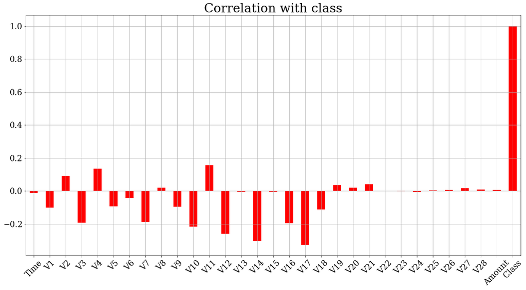

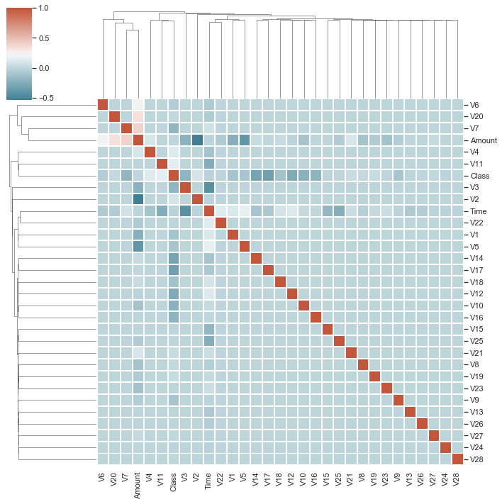

```python
#see the cluster and corralation of features and classes
def plot_corr(data = data_original, target = data_original.Class):

    ax1 = data.corrwith(target).plot.bar(figsize = (20, 10),
                                             title = "Correlation with class",
                                             fontsize = 18, color='r',
                                             rot = 45,
                                             grid = True)
    ax1.title.set_size(28)

    sns.set(style="white")
    cmap = sns.diverging_palette(220, 20, as_cmap=True)

    corr =data.corr()
    sns.clustermap(corr,cmap=cmap,
                  linewidths=1,linecolor='w')

plot_corr();
```

对于meta labeling来说，我们需要一个类别不均衡的数据，所以precision和recall不会同时变得很高。

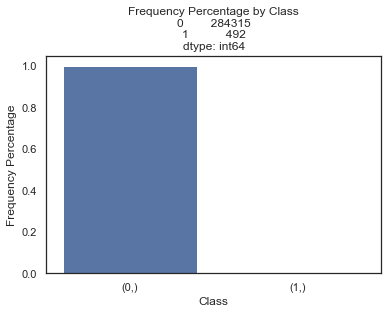

```python
val_counts = data_original[['Class']].value_counts()
ax = sns.barplot(x=val_counts.index,
                 y=val_counts/len(data_original))
ax.set(title=f'Frequency Percentage by {val_counts}',
       xlabel='Class',
       ylabel='Frequency Percentage');
```

## 评估标准

所以一般的算法会很容易欺骗我们，准确率往往会非常高，因为本来99.9%的数据就是 non-frauds，但是我们的目的是找到违约的情况，那么这个结果就是有欺骗性的，这就需要我们有更好的对于准确度的衡量标准！

- accuracy
- average_precision
- areaUnderROC
- precision
- recall
- f1-score
- confusion_matrix
- Precision-Recall Curve
- Area Under the Curve (AUC)

那么先来简单介绍一下这些 metrics

### 1. Recall, Precision and AUC (Area Under The Curve) ROC

这些指标比较相似，所以放在一起了。

#### Recall & Precision

[figure not shown]

#### ROC

ROC 曲线的 x 轴是 FPR，y 轴是 TPR，表示 TPR 对于 FPR 的敏感程度。AUC 是 ROC 曲线下方的面积，表示 TPR 和 FPR 之间的权衡关系，越大也好。

不同于 precision-recall 曲线，ROC 曲线对于均衡数据更有效

[figure not shown]

#### Average precision

[figure not shown]

本图显示了大概达到40%的recall时，不会牺牲任何的precision，但是达到100%的recall，就是牺牲掉50%的precision。

那么，average precision 是一个具体的数，用来表示分类器的表现，也就是上图中曲线下面的面积，对于所有 recall 对应的 precision 进行积分。

$$\int_{0}^{1}p(r)dr$$

实际当中，积分可由离散值的累加来代替

$$\sum_{k=1}^{N}p(k)\Delta r(k)\\ ~~~~~ where~~ \Delta r(k) ~~is ~~the ~~change ~~in ~~recall$$

https://sanchom.wordpress.com/tag/average-precision/

#### F1 score

F-score（亦被称做F-measure）是一种量测方法的精确度常用的指标，经常用来判断算法的精确度

[figure not shown]

一般式为

[figure not shown]

其中，$\beta=1$ 则变成了 F1 score,F-score最理想的数值是趋近于1，做法是让precision和recall都有很高的值。若两者皆为1，使得 ${\displaystyle 2\cdot {\frac {1}{2}}=1}$，则F-score = 1 （100%），代表该算法有着最佳的精确度。

#### Confusion matrix

混淆矩阵在面对高度的不均衡数据时显得乏力，不多介绍了。

[figure not shown]

```python
def metrics_summary(true_label, prediction_prob, Threshold=0.5):

    #basically, slearn provides all the functions for metrics.
    average_precision = average_precision_score(true_label
    ,prediction_prob)
    fpr, tpr, thresholds = roc_curve(true_label, prediction_prob)
    areaUnderROC = auc(fpr, tpr)

    prediction_int = prediction_prob > Threshold

    accuracy = accuracy_score(true_label, prediction_int)

    print(f'accuracy: {accuracy}')
    print(f"average_precision: {average_precision}")
    print(f'areaUnderROC--AUC: {areaUnderROC } \n')
    print('*'*60)
    print(' '*20, 'classification_report')
    print('*'*60, "\n")
    print(classification_report(true_label, prediction_int))

    print('*'*60)
    print(' '*20, 'confusion_matrix \n')
    print('*'*60, "\n")
    display(confusion_matrix(true_label, prediction_int))
    print("\n")

    # precision_recall_curve and areaUnderROC
    precision, recall, thresholds = precision_recall_curve( \
                                true_label, prediction_int)

    fig, (ax1, ax2) = plt.subplots(1, 2, figsize=(16,9))

    ax1.step(recall, precision, color='k', alpha=0.7, where='post')
    ax1.fill_between(recall, precision, step='post',
    alpha=0.3,color='k')
    ax1.set_xlabel('Recall', fontname="Arial", fontsize=24)
    ax1.set_ylabel('Precision', fontname="Arial", fontsize=24)
    ax1.tick_params(labelsize=20)

    ax1.set_title('Precision-Recall curve: Average Precision\
    ={0:0.2f}'.format(average_precision), fontsize=24,
    fontname="Arial")

    ax2.plot(fpr, tpr, color='r', lw=2, label='ROC curve')
    ax2.plot([0, 1], [0, 1], color='k', lw=2, linestyle='--')
    ax2.tick_params(labelsize=20)
    ax2.set_xlabel('False Positive Rate', fontname="Arial",
    fontsize=24)
    ax2.set_ylabel('True Positive Rate', fontname="Arial",
    fontsize=24)
    ax2.set_title('areaUnderROC = {0:0.2f}'\
            .format(areaUnderROC), fontsize=24, fontname="Arial",)
    ax2.legend(loc="lower right", fontsize=24, fancybox=True)
    # Adjust the subplot layout, because the logit one may take more space
    # than usual, due to y-tick labels like "1 - 10^{-3}"
    # plt.subplots_adjust(top=0.92, bottom=0.08, left=0.10,
    # right=0.95, hspace=0.25,wspace=0.35)
```

## 数据建模

采取下面几个模型：

1. 逻辑回归
2. lightGBM
3. DNN

这三个模型的相似度较低，所以期待他们的结果会有更强的差异性。

先来对数据进行一下预处理

### 预处理

```python
#Normalize training and testing data
def scale_data(x_train, x_test=None):
    features_to_scale = x_train.copy().columns
    scaler = pp.StandardScaler()
    print(scaler.fit(x_train[features_to_scale]))

    x_train.loc[:, features_to_scale] = \
    scaler.transform(x_train[features_to_scale])

    #normalize test dataset with the mean and std of train data set
    x_test.loc[:, features_to_scale] = \
    scaler.transform(x_test[features_to_scale])

    return x_train, x_test
#seperate input and labels
def get_x_y(data=data_original):
    data_x = data.copy().drop(['Class', 'Time'], axis=1)
    data_y = data['Class'].copy()

    return data_x, data_y
#split the train and test data
def data_split(data_x, data_y):
    x_train, x_test, y_train, y_test = \
          train_test_split(data_x,data_y,test_size=0.25,
          stratify=data_y,random_state=2020)
    # stratify 针对不均衡数据

    return  x_train, x_test, y_train, y_test
#put all together
def data_process(data=data_original):
    data_x, data_y = get_x_y(data)

    x_train, x_test, y_train, y_test \
    = data_split(data_x, data_y)

    #do not touch the test data by any means!!!!
    x_train, x_test = scale_data(x_train, x_test)

    return  x_train, x_test, y_train, y_test
```

```python
x_train, x_test_original, y_train, y_test_original \
= data_process(data_original)
x_train.shape, x_test_original.shape, \
y_train.shape, y_test_original.shape
```

```
StandardScaler(copy=True, with_mean=True, with_std=True)
```

```
((213605, 29), (71202, 29), (213605,), (71202,))
```

```python
print(f'No. of fraud in test dataset:\
      {x_test_original[y_test_original==1].shape[0]}')
```

```
No. of fraud in test dataset:      123
```

#### 逻辑回归

```python
def build_model_1(x_train, y_train):

    # parameters to be tuned
    logitreg_parameters = {'C': np.power(10.0, np.arange(-9, 1)),
                           'solver' : ('lbfgs', 'liblinear') }

    model_1 = LogisticRegression(#solver='liblinear',
                                 class_weight='balanced',
    #uses the values of y to automatically adjust weights

                                 warm_start=True,
    #reuse the solution of the previous call to fit
    # as initialization
                                 max_iter = 300,
    #Maximum number of iterations taken for the solvers to converge.
                                 random_state=2020,
    #so results can be reproduced
                                 )
    logitreg_grid = GridSearchCV(model_1, param_grid = \
           logitreg_parameters,scoring = 'f1', n_jobs = 1, cv=5)

    logitreg_grid.fit(x_train, y_train)

    return logitreg_grid

model_1 = build_model_1(x_train, y_train)
```

```python
model_1.best_estimator_
```

```
LogisticRegression(C=1e-06, class_weight='balanced', dual=False,
                   fit_intercept=True, intercept_scaling=1, l1_ratio=None,
                   max_iter=300, multi_class='auto', n_jobs=None, penalty='l2',
                   random_state=2020, solver='lbfgs', tol=0.0001, verbose=0,
                   warm_start=True)
```

```python
model_1.best_score_
```

```
0.8071220159151193
```

```python
# 0 and 1 two clasese
y_pred_prob_test_1 = model_1.predict_proba(x_test_original)[:,1]
# number of fraud is 123 in test dataset
Threshold = 0.5
y_pred_int_test_1 = y_pred_prob_test_1 > Threshold
pd.Series(y_pred_int_test_1).value_counts()
```

```
False    71075
True       127
dtype: int64
```

```
accuracy: 0.9993820398303418
average_precision: 0.6794307533509736
areaUnderROC--AUC: 0.9185303607562729

                     classification_report

              precision    recall  f1-score   support

           0       1.00      1.00      1.00     71079
           1       0.81      0.84      0.82       123

    accuracy                           1.00     71202
   macro avg       0.91      0.92      0.91     71202
weighted avg       1.00      1.00      1.00     71202

                     confusion_matrix
```

```
array([[71055,    24],
       [   20,   103]], dtype=int64)
```

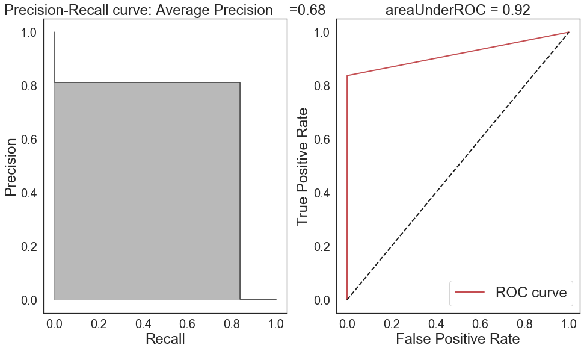

```python
metrics_summary(y_test_original, y_pred_int_test_1)
```

#### lightGBM

```python
#prepare data
x_train_, x_cv, y_train_, y_cv = \
train_test_split(x_train, y_train,
                test_size=0.25,
                stratify=y_train,
                random_state=2020)

def build_model_2(x_train, y_train, x_cv, y_cv ):
    #most of the parsmeters are default
    params_lightGB = {
    'task': 'train',
    'application':'binary',
    'num_class':1,
    'boosting': 'gbdt',
    'objective': 'binary',
    'metric': 'binary_logloss',
    'metric_freq':50,
    'is_training_metric':False,
    'max_depth':4,
    'num_leaves': 31,
    'learning_rate': 0.01,
    'feature_fraction': 1.0,
    'bagging_fraction': 1.0,
    'bagging_freq': 0,
    'bagging_seed': 2018,
    'verbose': 0,
    'num_threads':16
    }
    lgb_train = lgb.Dataset(x_train, y_train)
    lgb_eval = lgb.Dataset(x_cv, y_cv, reference=lgb_train)
    model_2 = lgb.train(params_lightGB, lgb_train,
                    num_boost_round=2000,
                    valid_sets=lgb_eval,
                    early_stopping_rounds=200,
                    verbose_eval=False)
    return model_2
x_train_.shape, y_train_.shape, x_cv.shape, y_cv.shape
```

```
((160203, 29), (160203,), (53402, 29), (53402,))
```

```python
model_2 = build_model_2(x_train_, y_train_, x_cv, y_cv)
y_pred_prob_test_2 = model_2.predict(x_test_original)
y_pred_int_test_2 = y_pred_prob_test_2 > Threshold
pd.DataFrame(y_pred_int_test_2).value_counts()
```

[output not shown]

[output cut: 173 more lines]

[output not shown]

```
False    71100
True       102
dtype: int64
```

```
accuracy: 0.9995084407741356
average_precision: 0.7197460291438034
areaUnderROC--AUC: 0.8861296208032355

                     classification_report

              precision    recall  f1-score   support

           0       1.00      1.00      1.00     71079
           1       0.93      0.77      0.84       123

    accuracy                           1.00     71202
   macro avg       0.97      0.89      0.92     71202
weighted avg       1.00      1.00      1.00     71202

                     confusion_matrix
```

```
array([[71072,     7],
       [   28,    95]], dtype=int64)
```

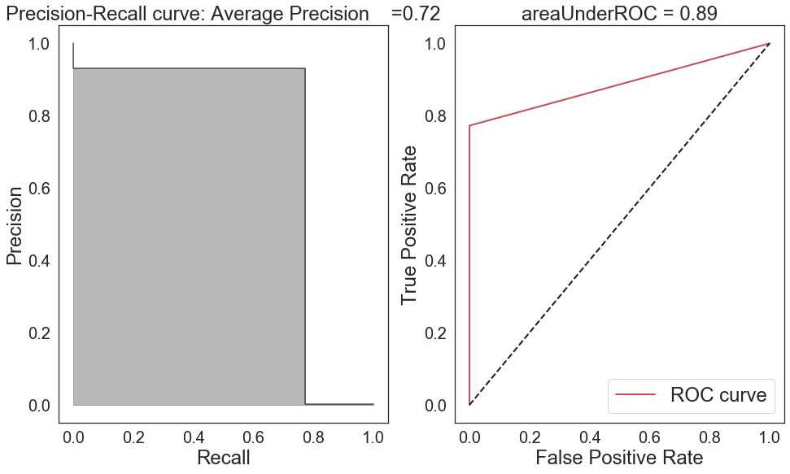

```python
metrics_summary(y_test_original, y_pred_int_test_2)
```

可以看出，accuracy 非常高，这是我们所预料的，但是 recall = 77% 相对一般

#### DNN

```python
callbacks = [EarlyStopping(monitor='loss', patience=3), \
                 ReduceLROnPlateau(monitor='val_loss', factor=0.2, \
                                   patience=3, min_lr=0.001)]
def build_model_3(x_train, y_train, x_cv, y_cv, input_dim=29):
    model_3 = Sequential([
                Dense(input_dim = input_dim, units = 32,
                      activation  = 'relu'),
                Dense(units = 16, activation =  'relu'),
                #Dropout(0.5),
                Dense(units = 8, activation =  'relu'),
                # Dense(units = 4, activation =  'relu')，
                Dense(units =1, activation = 'sigmoid'),])
    model_3.compile(optimizer = 'adam',
                 loss = 'binary_crossentropy',
                 metrics = ['accuracy'])

    model_3.fit(x_train, y_train,
              validation_data = (x_cv, y_cv),
              batch_size = 64,
              epochs = 50,
              callbacks=callbacks)

    return model_3
```

```python
model_3 = build_model_3(x_train_, y_train_, \
x_cv, y_cv, input_dim=29)
y_pred_prob_test_3 = model_3.predict(x_test_original)
y_pred_int_test_3 = y_pred_prob_test_3 > Threshold
y_pred_int_test_3.shape
pd.DataFrame(y_pred_int_test_3).value_counts()
```

```
False    71094
True       108
dtype: int64
```

```
accuracy: 0.9994803516755147
average_precision: 0.7086608523501224
areaUnderROC--AUC: 0.8942315643981156

                     classification_report

              precision    recall  f1-score   support

           0       1.00      1.00      1.00     71079
           1       0.90      0.79      0.84       123

    accuracy                           1.00     71202
   macro avg       0.95      0.89      0.92     71202
weighted avg       1.00      1.00      1.00     71202

                     confusion_matrix
```

```
array([[71068,    11],
       [   26,    97]], dtype=int64)
```

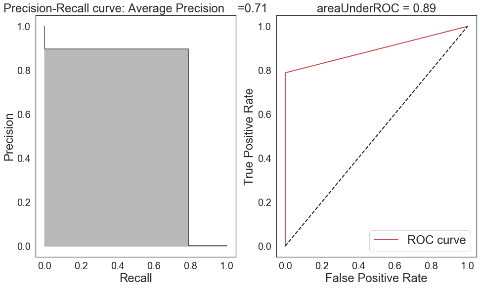

```python
metrics_summary(y_test_original, y_pred_int_test_3)
```

那么现在把这些模型堆叠起来

## Stacking

其实 stacking 就像是向原始数据中加入新的特征，并且新的特征来自于一级模型的预测，那么先来做一下特征工程，把所有数据堆叠一下。

```python
def data_stack( x, y, m_1=model_1, m_2=model_2, m_3=model_3):
    # All required parameters must be placed before any
    # default arguments.
    '''
    x: features
    y: labels
    m_1, m_2, m_3: 3 models

    '''
    # build a container to hold all the prediction from 3 models
    pred_all = pd.DataFrame(data=[], index=y.index)
    pred_1 = m_1.predict_proba(x)[:,1]
    pred_1_df = pd.DataFrame(pred_1, index=y.index)

    pred_2 = m_2.predict(x,num_iteration=m_2.best_iteration)
    pred_2_df = pd.DataFrame(pred_2, index=y.index)

    pred_3 = m_3.predict(x).reshape(x.shape[0]) #to 1D shape
    pred_3_df = pd.DataFrame(pred_3, index=y.index)
   # join all the predictions together
    pred_all = pred_all.join(pred_1_df.astype(float),
                             how='left',rsuffix="0")\
                       .join(pred_2_df.astype(float),
                             how='left',rsuffix="1")\
                       .join(pred_3_df.astype(float),
                             how='left',rsuffix="2")
    pred_all.columns = ['pred_1', 'pred_2','pred_3']
    # final training data will be the merge of training data
    # and all the predictions
    x_pred = x.merge(pred_all, \
                    left_index=True, right_index=True)

    print(x_pred.shape)
    return x_pred
```

```python
x_train_stack = data_stack(x_train, y_train)
```

```
(213605, 32)
```

```python
x_test_stack = data_stack(x_test_original, y_test_original)
```

```
(71202, 32)
```

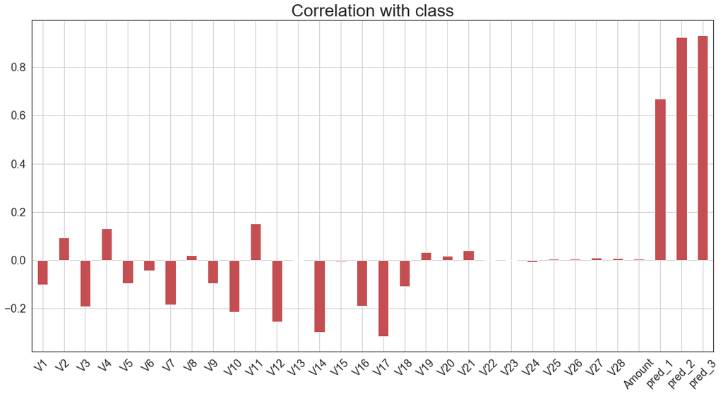

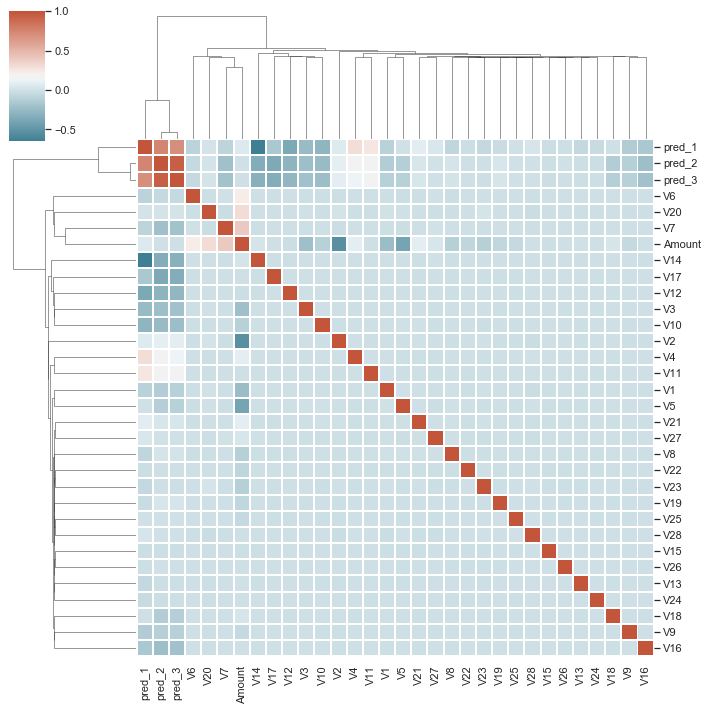

```python
plot_corr(data=x_train_stack,target=y_train)
```

我们发现一级模型得到的 prediction 是高度相关的，这并不意外。1st model 的信息泄露到 2nd model 因为他们共享了一样的训练数据。只要测试集是原封不动的，我们反而更愿意有更多的信息涌入 2nd model 从而有更好的预测结果。

继续对堆叠数据进行数据处理

```python
#normalize training and testing data
x_train_stack, x_test_stack = scale_data(x_train_stack,  x_test_stack)
#split the traning data to train and validation
x_train_stack_, x_cv_stack, y_train_, y_cv_ = \
train_test_split(x_train_stack, y_train,
                test_size=0.25,
                stratify=y_train,
                random_state=2020)
#stratify mean samplling with the ratio of each class percentage in #all data.
x_train_stack_.shape, x_cv_stack.shape, y_train_.shape,  y_cv.shape
```

```
StandardScaler(copy=True, with_mean=True, with_std=True)
```

```
((160203, 32), (53402, 32), (160203,), (53402,))
```

注意：

如果单独的算法得到的结果都很好，那么合在一起会更好；如果其中一个算法要远远强于其他的，那么合在一起并不会有什么提升，顶多就和最好的那个一样好。

#### Model 2 (lightBGM) as the secondary model

```python
model_2_stack = build_model_2(x_train_stack_, y_train_, x_cv_stack, y_cv_)
y_pred_prob_test_2_stack = model_2_stack.predict(x_test_stack)
y_pred_int_test_2_stack = y_pred_prob_test_2_stack > Threshold
pd.DataFrame(y_pred_int_test_2_stack).value_counts()
```

[output not shown]

[output cut: 314 more lines]

[output not shown]

```
False    71084
True       118
dtype: int64
```

```
accuracy: 0.9994803516755147
average_precision: 0.717120069888557
areaUnderROC--AUC: 0.9145215955177319

                     classification_report

              precision    recall  f1-score   support

           0       1.00      1.00      1.00     71079
           1       0.86      0.83      0.85       123

    accuracy                           1.00     71202
   macro avg       0.93      0.91      0.92     71202
weighted avg       1.00      1.00      1.00     71202

                     confusion_matrix
```

```
array([[71063,    16],
       [   21,   102]], dtype=int64)
```

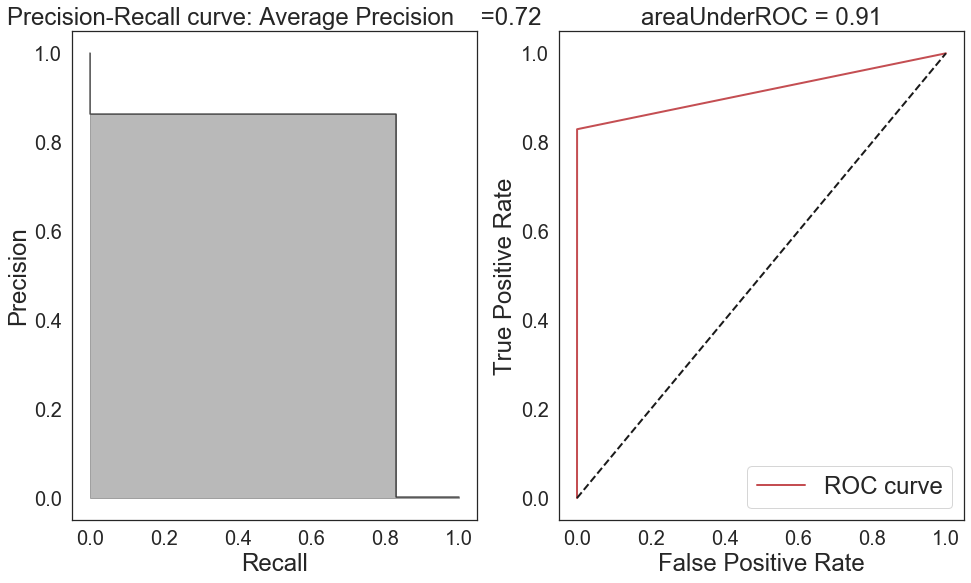

```python
metrics_summary(y_test_original, y_pred_int_test_2_stack)
```

#### Model 3 DNN as the secondary model

```python
model_3_stack = build_model_3(x_train_stack_, y_train_, \
                        x_cv_stack, y_cv_, input_dim=32)
y_pred_prob_test_3_stack = model_3_stack.predict(x_test_stack)
y_pred_int_test_3_stack = y_pred_prob_test_3_stack > Threshold
y_pred_int_test_3_stack.shape
pd.DataFrame(y_pred_int_test_3_stack).value_counts()
```

```
False    71091
True       111
dtype: int64
```

```
accuracy: 0.999522485323446
average_precision: 0.7327627814641402
areaUnderROC--AUC: 0.9064266863493351

                     classification_report

              precision    recall  f1-score   support

           0       1.00      1.00      1.00     71079
           1       0.90      0.81      0.85       123

    accuracy                           1.00     71202
   macro avg       0.95      0.91      0.93     71202
weighted avg       1.00      1.00      1.00     71202

                     confusion_matrix
```

```
array([[71068,    11],
       [   23,   100]], dtype=int64)
```

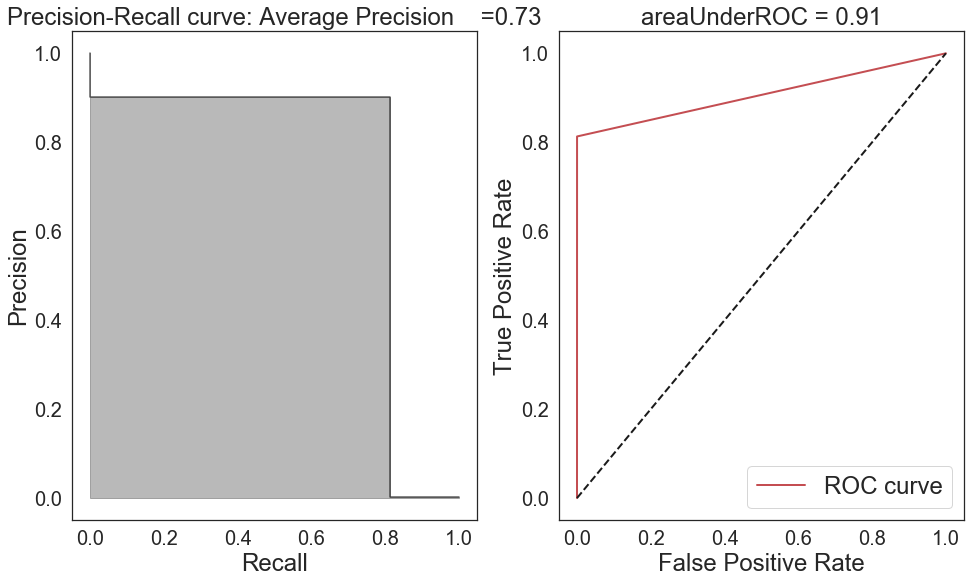

```python
metrics_summary(y_test_original, y_pred_int_test_3_stack)
```

#### Model 1 logistic regression as the secondary model

```python
model_1_stack = build_model_1(x_train_stack, y_train)
model_1_stack.best_score_
```

```
0.895382284855969
```

其实还不错

```python
y_pred_prob_test_1_stack = model_1_stack.predict_proba(x_test_stack)[:,1]# 0 and 1 two clases
y_pred_int_test_1_stack = y_pred_prob_test_1_stack > Threshold
pd.Series(y_pred_int_test_1_stack).value_counts()
```

```
False    71082
True       120
dtype: int64
```

```
accuracy: 0.9994803516755147
average_precision: 0.7190478286555848
areaUnderROC--AUC: 0.9185796017416554

                     classification_report

              precision    recall  f1-score   support

           0       1.00      1.00      1.00     71079
           1       0.86      0.84      0.85       123

    accuracy                           1.00     71202
   macro avg       0.93      0.92      0.92     71202
weighted avg       1.00      1.00      1.00     71202

                     confusion_matrix
```

```
array([[71062,    17],
       [   20,   103]], dtype=int64)
```

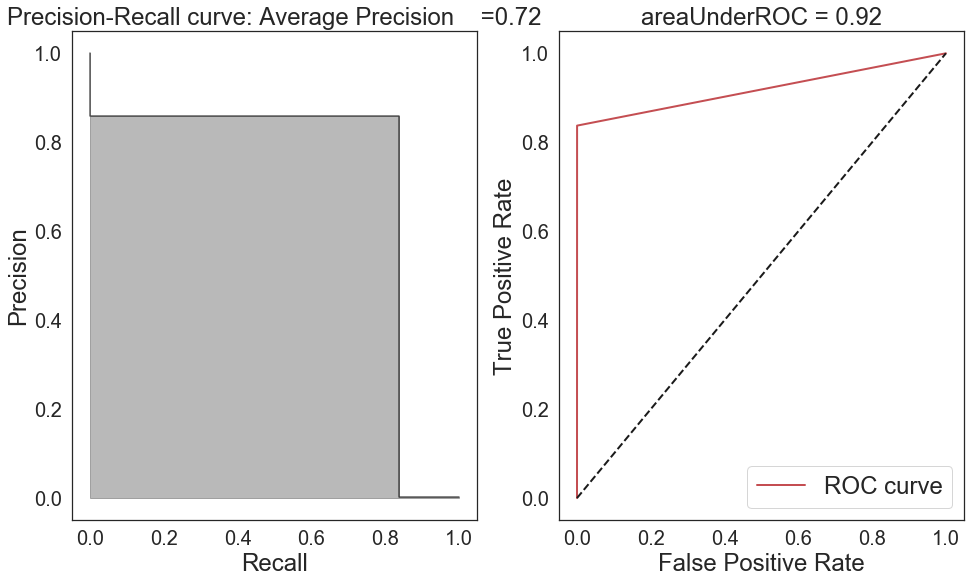

```python
metrics_summary(y_test_original, y_pred_int_test_1_stack)
```

多多少少在 stack 之后比之前有了一些提升，而且也不必 lightGBM 和 DNN 差

## 元标签

由于 meta labeling 需要对输入数据和label都要添加新的特征，需要对之前的代码做一些调整

```python
def data_meta(id, x, y, model):
    #get prediction from model 1
    Threshold = 0.5
    pred_prob_meta = model.predict_proba(x)[:,1]
    pred_prob_meta = pd.Series(pred_prob_meta, \
                               index=x.index,
                               name=f'pred_{id}_meta')
    pred_int_meta = pred_prob_meta > Threshold
    y_meta = pd.Series(y & pred_int_meta, name=f'y_train_meta_{id}')
    x_meta = x.join(pred_int_meta)

    return x_meta, y_meta
```

### 1st model: logreg and 2nd model: lightBGM

```python
x_train_meta_1, y_train_meta_1 = \
data_meta(1, x_train, y_train, model_1)
x_train_meta_1.shape, y_train_meta_1.shape
```

```
((213605, 30), (213605,))
```

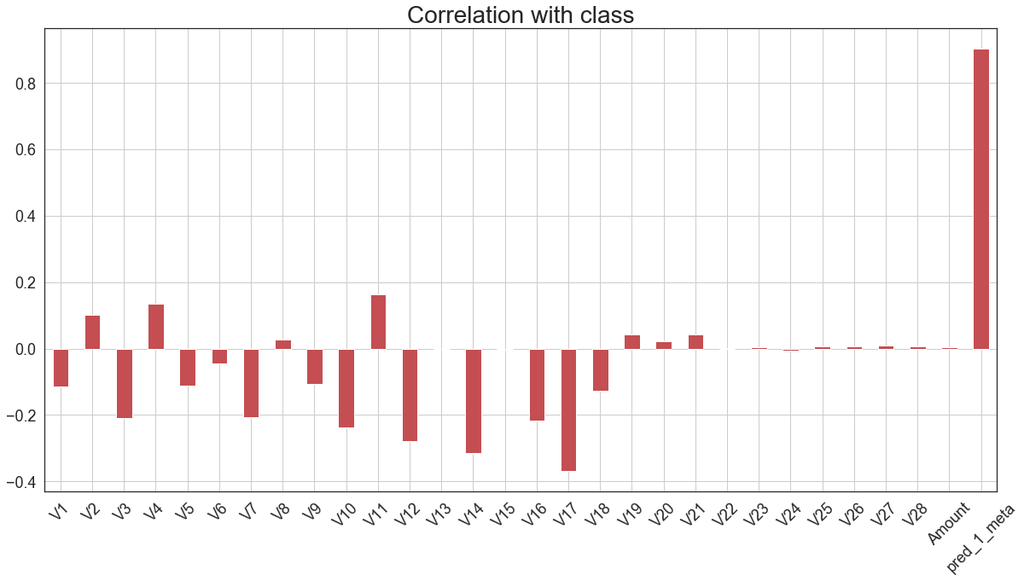

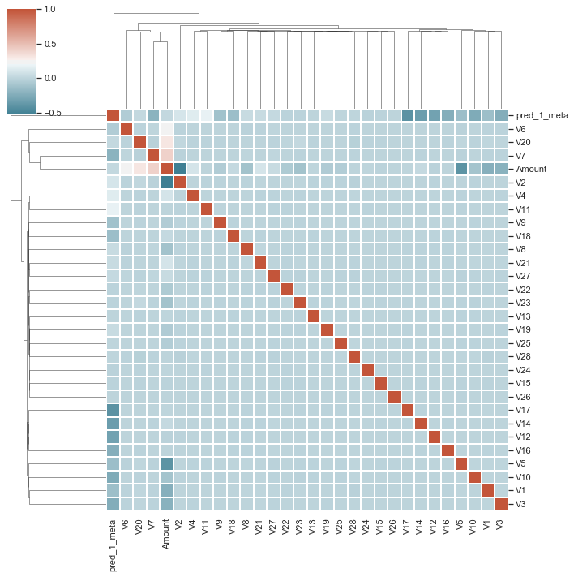

```python
plot_corr(x_train_meta_1, y_train_meta_1);
```

看得出，从一级模型而来的预测值和 label 有相当强的相关性

```python
# test data
x_test_meta_1, y_test_meta_1 = \
data_meta(1, x_test_original, y_test_original, model_1)
x_test_meta_1.shape, y_test_meta_1.shape
```

```
((71202, 30), (71202,))
```

```python
x_train_meta_1, x_test_meta_1 = scale_data( \
                                x_train_meta_1, x_test_meta_1)
```

```
StandardScaler(copy=True, with_mean=True, with_std=True)
```

```python
x_train_meta_1_, x_cv_meta_1, y_train_meta_1_, y_cv_meta_1 = \
train_test_split(x_train_meta_1, y_train_meta_1,
                test_size=0.25,
                stratify=y_train_meta_1,
                random_state=2020)
#stratify mean samplling with the ratio of each class percentage in #all data.
x_train_meta_1_.shape, x_cv_meta_1.shape, y_train_meta_1_.shape,  y_cv_meta_1.shape
```

```
((160203, 30), (53402, 30), (160203,), (53402,))
```

```python
model_2_meta_1 = build_model_2( \
    x_train_meta_1_, y_train_meta_1_, x_cv_meta_1, y_cv_meta_1)
y_pred_prob_test_2_meta_1 = model_2_meta_1.predict(x_test_meta_1)
y_pred_int_test_2_meta_1 = y_pred_prob_test_2_meta_1 > Threshold
pd.DataFrame(y_pred_int_test_2_meta_1).value_counts()
```

[output not shown]

[output cut: 880 more lines]

[output not shown]

```
False    71098
True       104
dtype: int64
```

在我们从 meta model 得到预测值之后，我们把这个结果和一级模型合并起来

```python
final_pred_2_meta_1 = y_pred_int_test_2_meta_1 &  y_pred_int_test_1
pd.DataFrame(final_pred_2_meta_1).value_counts()
```

```
False    71098
True       104
dtype: int64
```

```
accuracy: 0.9996207971686188
average_precision: 0.7820616112507749
areaUnderROC--AUC: 0.9064759273347175

                     classification_report

              precision    recall  f1-score   support

           0       1.00      1.00      1.00     71079
           1       0.96      0.81      0.88       123

    accuracy                           1.00     71202
   macro avg       0.98      0.91      0.94     71202
weighted avg       1.00      1.00      1.00     71202

                     confusion_matrix
```

```
array([[71075,     4],
       [   23,   100]], dtype=int64)
```

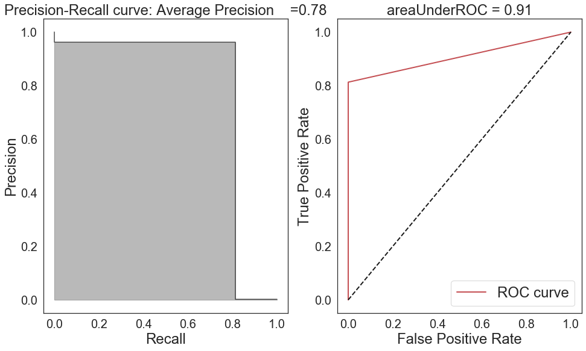

```python
metrics_summary(y_test_original, final_pred_2_meta_1)
```

虽然总体看起来没什么不同，但是拆开成不同的指标来看，可以看出 precision 和 recall 更均衡了

### 1st model: logreg and 2nd model: DNN

```python
#if you receive an error message, try to run the data process again.
model_3_meta_1 = build_model_3( \
    x_train_meta_1_, y_train_meta_1_, \
    x_cv_meta_1, y_cv_meta_1, input_dim=30)
y_pred_prob_test_3_meta_1 = model_3_meta_1.predict(x_test_meta_1)
y_pred_int_test_3_meta_1 = y_pred_prob_test_3_meta_1 > Threshold
pd.DataFrame(y_pred_int_test_3_meta_1).value_counts()
```

```
False    71093
True       109
dtype: int64
```

```python
# combine the  meta prediction with primary prediction
final_pred_3_meta_1 = y_pred_int_test_3_meta_1.flatten() & y_pred_int_test_1
final_pred_3_meta_1.shape
```

```
(71202,)
```

```
accuracy: 0.999522485323446
average_precision: 0.7313730951400398
areaUnderROC--AUC: 0.9023686801254118

                     classification_report

              precision    recall  f1-score   support

           0       1.00      1.00      1.00     71079
           1       0.91      0.80      0.85       123

    accuracy                           1.00     71202
   macro avg       0.95      0.90      0.93     71202
weighted avg       1.00      1.00      1.00     71202

                     confusion_matrix
```

```
array([[71069,    10],
       [   24,    99]], dtype=int64)
```

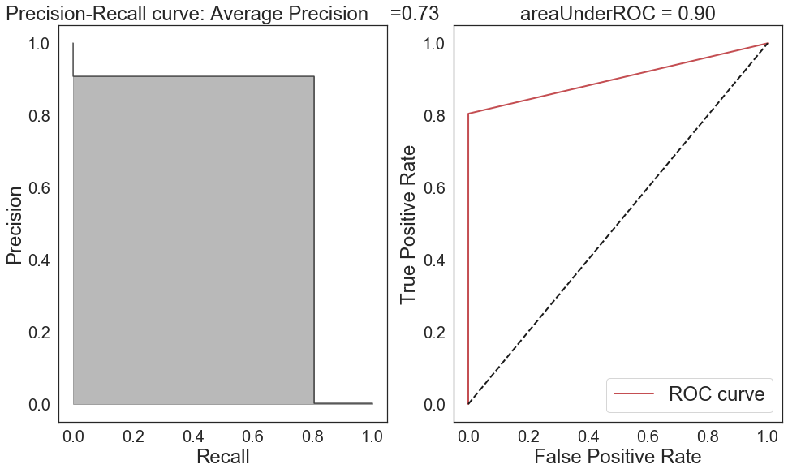

```python
metrics_summary(y_test_original, final_pred_3_meta_1)
```

貌似 precision 更高了，但代价是 recall 降低了一些

#### 3. 1st model: logreg + lightBGM and 2nd model: DNN

```python
def data_meta_2(id, x, y, m_1, m_2):
    '''
    id: the id of new columns
    x: input features
    y: labels
    m_1: model 1, here logreg
    m_2: model 2
    '''
    pred_prob_meta_1 = m_1.predict_proba(x)[:,1]
    pred_prob_meta_1 = pd.Series(pred_prob_meta_1, \
                                 index=x.index,
                                 name=f'pred_{id}_meta')
    pred_int_meta_1 = pred_prob_meta_1 > Threshold

    pred_prob_meta_2 = m_2.predict(x)
    #as DNN give 2D prediction that needs to be flatten to 1D for
    #combination
    pred_prob_meta_2 = pd.Series(pred_prob_meta_2.flatten(), \
                                 index=x.index,
                                 name=f'pred_{id+1}_meta')
    pred_int_meta_2 = pred_prob_meta_2 > Threshold

    y_meta = pd.Series(y & pred_int_meta_1 & pred_int_meta_2, \
                       name=f'y_train_meta_{id}')
    x_meta = x.join(pred_int_meta_1).join(pred_int_meta_2)

    return x_meta, y_meta

#meta_1_2: meta data from 1 model and 2 model
x_train_meta_1_2, y_train_meta_1_2 = \
data_meta_2(1, x_train, y_train, model_1, model_2)
x_test_meta_1_2, y_test_meta_1_2 = \
data_meta_2(1, x_test_original, y_test_original, model_1, model_2)

x_train_meta_1_2, x_test_meta_1_2 = \
scale_data(x_train_meta_1_2, x_test_meta_1_2)

x_train_meta_1_2_, x_cv_meta_1_2, y_train_meta_1_2_, y_cv_meta_1_2 = \
train_test_split(x_train_meta_1_2, y_train_meta_1_2,
                test_size=0.25,
                stratify=y_train_meta_1_2,
                random_state=2020)
#stratify mean samplling with the ratio of each class percentage in #all data.
x_train_meta_1_2_.shape, x_cv_meta_1_2.shape, \
y_train_meta_1_2_.shape,  y_cv_meta_1_2.shape
```

```
StandardScaler(copy=True, with_mean=True, with_std=True)
```

```
((160203, 31), (53402, 31), (160203,), (53402,))
```

```python
model_3_meta_1_2 = build_model_3( \
    x_train_meta_1_2_, y_train_meta_1_2_, \
    x_cv_meta_1_2, y_cv_meta_1_2, input_dim=31)
y_pred_prob_test_3_meta_1_2 = model_3_meta_1_2.predict(x_test_meta_1_2)
y_pred_int_test_3_meta_1_2 = y_pred_prob_test_3_meta_1_2 > Threshold
pd.DataFrame(y_pred_int_test_3_meta_1_2).value_counts()
```

```
False    71109
True        93
dtype: int64
```

```python
# combine the  meta prediction with primary prediction
final_pred_3_meta_1_2 = \
y_pred_int_test_3_meta_1_2.flatten() & \
y_pred_int_test_1 & y_pred_int_test_2
pd.Series(final_pred_3_meta_1_2).value_counts()
```

```
False    71109
True        93
dtype: int64
```

最后一步并没有任何改变，看看具体的指标

```
accuracy: 0.9994943962248252
average_precision: 0.7085673253593443
areaUnderROC--AUC: 0.8658325552571358

                     classification_report

              precision    recall  f1-score   support

           0       1.00      1.00      1.00     71079
           1       0.97      0.73      0.83       123

    accuracy                           1.00     71202
   macro avg       0.98      0.87      0.92     71202
weighted avg       1.00      1.00      1.00     71202

                     confusion_matrix
```

```
array([[71076,     3],
       [   33,    90]], dtype=int64)
```

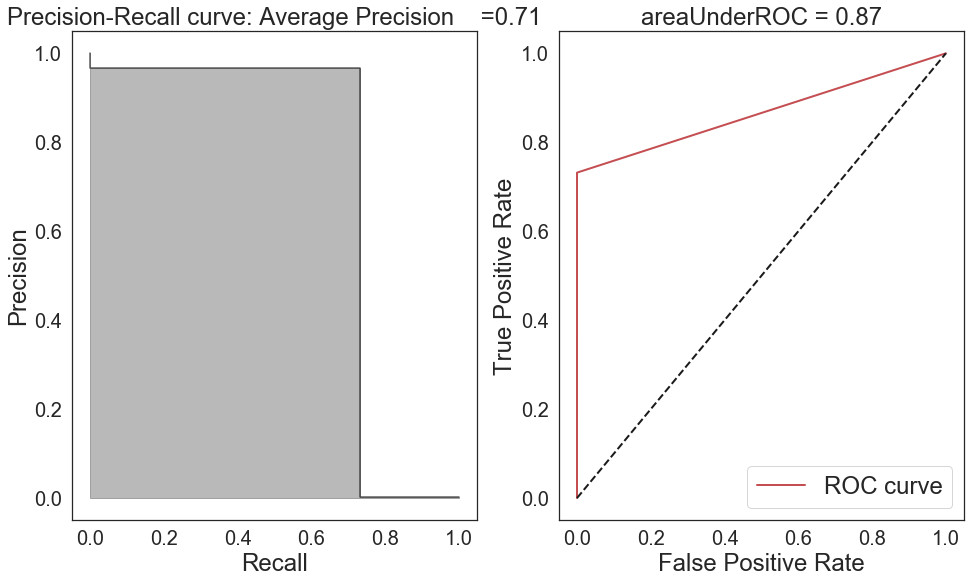

```python
metrics_summary(y_test_original, y_pred_int_test_3_meta_1_2)
```

综合起来还是不错的，但是 recall 还是稍微低了一点

#### 4. 1st model: logreg + DNN and 2nd model: lightBGM

由于看起来 lightGBM 作为 2nd model 会更好一些，那么再来试一试

```python
#meta_1_3: meta data from 1 model and 2 model
#process the train dataset
x_train_meta_1_3, y_train_meta_1_3 = \
data_meta_2(1, x_train, y_train, model_1, model_3)
#meta_1_3: meta data from 1st model and 3rd model
#process the test dataset
x_test_meta_1_3, y_test_meta_1_3 = \
data_meta_2(1, x_test_original, y_test_original, model_1, model_3)
#normalize the dataset
x_train_meta_1_3, x_test_meta_1_3 = \
scale_data(x_train_meta_1_3, x_test_meta_1_3)
#do a train, validation split
x_train_meta_1_3_, x_cv_meta_1_3, y_train_meta_1_3_, y_cv_meta_1_3 = \
train_test_split(x_train_meta_1_3, y_train_meta_1_3,
                test_size=0.25,
                stratify=y_train_meta_1_3,
                random_state=2020)
```

```
StandardScaler(copy=True, with_mean=True, with_std=True)
```

```python
model_2_meta_1_3 = build_model_2( \
    x_train_meta_1_3_, y_train_meta_1_3_, \
    x_cv_meta_1_3, y_cv_meta_1_3)
```

[output not shown]

[output cut: 421 more lines]

[output not shown]

```python
y_pred_prob_test_2_meta_1_3 = model_2_meta_1_3.predict(x_test_meta_1_3)
y_pred_int_test_2_meta_1_3 = y_pred_prob_test_2_meta_1_3 > Threshold
# combine the  meta prediction with primary prediction
final_pred_2_meta_1_3 = \
y_pred_int_test_2_meta_1_3 & \
y_pred_int_test_1 & y_pred_int_test_3.flatten()
pd.Series(final_pred_2_meta_1_3).value_counts()
```

```
False    71100
True       102
dtype: int64
```

```
accuracy: 0.9995365298727564
average_precision: 0.7349559603636624
areaUnderROC--AUC: 0.8902016958801252

                     classification_report

              precision    recall  f1-score   support

           0       1.00      1.00      1.00     71079
           1       0.94      0.78      0.85       123

    accuracy                           1.00     71202
   macro avg       0.97      0.89      0.93     71202
weighted avg       1.00      1.00      1.00     71202

                     confusion_matrix
```

```
array([[71073,     6],
       [   27,    96]], dtype=int64)
```

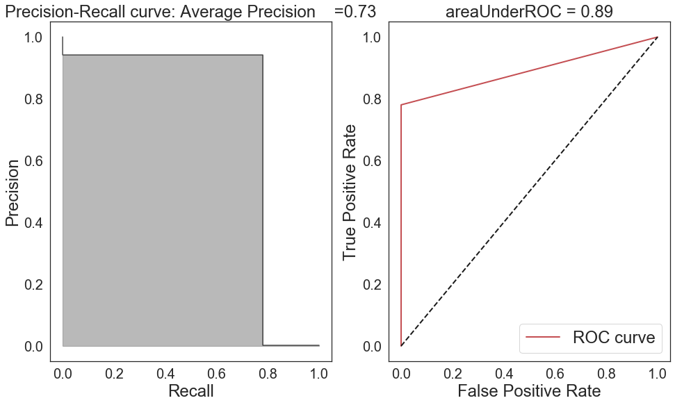

```python
metrics_summary(y_test_original, final_pred_2_meta_1_3)
```

## 特征重要性

```python
def plot_feature_importance(model, X , importance_type = 'split'):
    # split就是特征在所有决策树中被用来分割的总次数。
    # gain就是特征在所有决策树种被用来分割后带来的增益(gain)总和
    feature_imp = pd.DataFrame({'Value':model.
                               feature_importance(importance_type),
                               'Feature':X.columns})
    f, ax = plt.subplots(figsize=(40, 30))
    ax.set_title(f'LightGBM Features Importance by {importance_type}', fontsize=75, fontname="Arial")
    ax.set_xlabel('Features', fontname="Arial", fontsize=70)
    ax.set_ylabel('Importance', fontname="Arial", fontsize=70)
    ax.tick_params(labelsize=50)

    sns.barplot(x="Value", y="Feature",
                data=feature_imp.sort_values(by="Value",
                ascending=False), ax=ax)
```

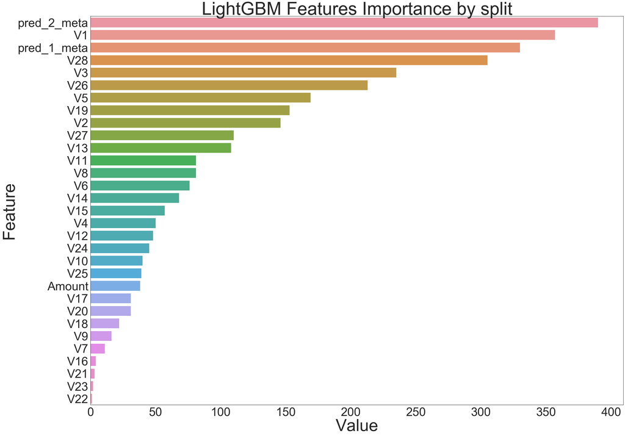

```python
plot_feature_importance(model_2_meta_1_3, x_train_meta_1_3_)
```

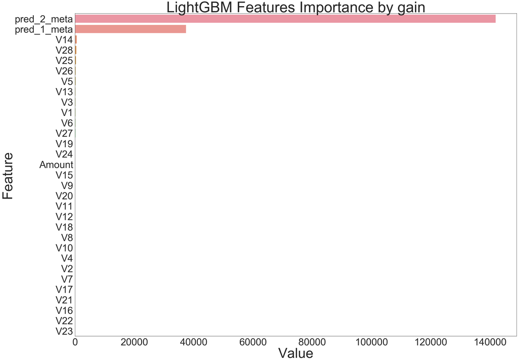

```python
plot_feature_importance(model_2_meta_1_3, x_train_meta_1_3_, 'gain')
```

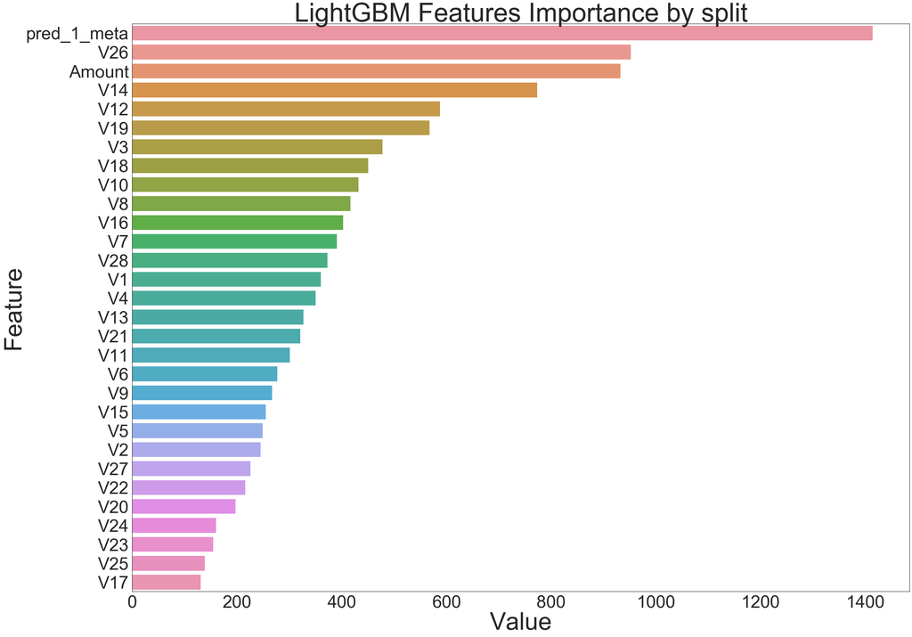

```python
plot_feature_importance(model_2_meta_1, x_train_meta_1_)
```

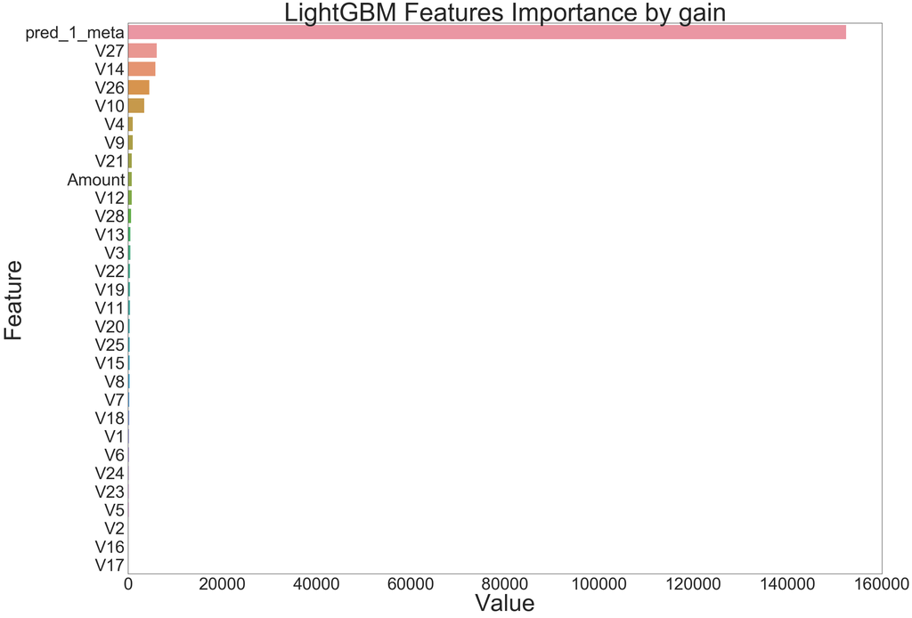

```python
plot_feature_importance(model_2_meta_1, x_train_meta_1_, 'gain')
```

## 高评分困惑

我们知道从一级模型到次级模型是有信息泄露的，但是这是我们想要的结果，只要我们保证测试集的完整性即可。

如果存在从测试集到训练集的信息泄露情况的话，那这种影响会被放大，DNN 善于利用这一弊病而得到高分。

```python
data_original.columns[:-1]
```

```
Index(['Time', 'V1', 'V2', 'V3', 'V4', 'V5', 'V6', 'V7', 'V8', 'V9', 'V10',
       'V11', 'V12', 'V13', 'V14', 'V15', 'V16', 'V17', 'V18', 'V19', 'V20',
       'V21', 'V22', 'V23', 'V24', 'V25', 'V26', 'V27', 'V28', 'Amount'],
      dtype='object')
```

```python
#normalize all the data in one go.

features_to_scale = data_original.columns[1:-1]
scaler = pp.StandardScaler()
data_original.loc[:, features_to_scale] = scaler.fit_transform(data_original[features_to_scale])
#split training and testing dataset afterwards.
x_train_cv, x_test, y_train_cv, y_test \
= train_test_split(data_original.loc[:, features_to_scale], data_original.Class, test_size=0.25,\
                   stratify=data_original.Class,random_state=2020)
```

## 金融资产数据的元标签法

在给金融资产数据打标签的整个流程分为两步：

确定基础标签 ybase：用〖三隔栏方法〗一贴介绍的方法

1. 当 ybase = 1 时，止盈隔栏先被触及
2. 当 ybase = -1 时，止损隔栏先被触及
3. 当 ybase = 0 时，垂直隔栏先被触及

确定元标签 ymeta：即是否按着头寸方向交易

1. 当 ybase = 1 并且 rtrue > c 而触发止盈时，设置ymeta = 1；当 ybase = -1 并且 rtrue < -c 而触发止损时，设置 ymeta = 1
2. 其他情况统统设置 ymeta = 0。

[figure not shown]

随后我们对模型预测的正例使用元标签，并建立次级模型来提高查准率。该模型的主要目的是从已经挑选出的机会中再一次筛选投资标的。

当**次级模型**是机器学习相关模型时，就有意思了。因此机器学习中的分类器不仅能返回类别，而且可以返回类别对应的概率，概率越大，预测该类别的信心越足，那么在交易时不就可以增加头寸大小了么？

元标签方法可以看成是一个次级模型，其美妙之处在于，你可以把元标签方法可加载任何初级模型上，不管它是

- 机器学习模型
- 计量经济学公式
- 基本面分析
- 技术分析
- 人主观看法

它有以下几点优势：

1. 提升了模型的可解读性。先通过简单模型（如基本面或者人的看法）来确定头寸方向，随后再使用复杂模型（如机器学习模型）
2. 限制了过拟合。在元标签之后，复杂模型将只决定头寸大小而非方向
3. 头寸方向和头寸大小的分解允许我们先简后繁。例如我们可以使用复杂模型分别对多头和空头进行专门训练确定头寸大小

## 总结

对于金融资产数据，元标签是指在第一个模型已经确定头寸方向的情况下，希望通过第二个模型来确定头寸大小。

而预测该类的概率是任何机器学习的分类模型的副产品，在 scikit-learn 中，用 `predict_proba()` 可以得到预测概率。

假设我们用随机森林预测出概率为 p，在实际交易中，一种决策可以是

- p < 55%，不要做多
- p ∈ [55%, 60%]，用 50% 资金做多
- p > 60%，用 100% 资金做多

当初级模型用主观看法，而次级模型用客观数据，这种投资方法称为**量化基本面投资（Quantitative Fundamental, Quantamental）**。

> Quantamental refers to an investment strategy that combines quantitative approaches using computers, mathematical models, and big data with fundamental methods that analyze individual company cash flows, growth, and risk to generate better risk-adjusted returns.

> 量化基本面投资其实是一种对基本面投资和量化投资的融合，是将计算机算法与人类的分析结合起来的一种 1+1>2 的新型投资方式。

[figure not shown]

### Reference

1. [Introduction to “Advances in Financial Machine Learning” by Lopez de Prado](https://www.quantopian.com/posts/introduction-to-advances-in-financial-machine-learning-by-lopez-de-prado)
2. [Measuring Performance: AUC (AUROC)](https://glassboxmedicine.com/2019/02/23/measuring-performance-auc-auroc/)
3. [A Pirate’s Guide to Accuracy, Precision, Recall, and Other Scores](https://blog.floydhub.com/a-pirates-guide-to-accuracy-precision-recall-and-other-scores/)
4. [Average precision](https://sanchom.wordpress.com/tag/average-precision/)
5. How to Calculate Feature Importance With Python